# Dollar Cost Averaging and Value-Averaging Investement Strategies Comparison

## Introduction

This project examines and compares two popular investment strategies: Dollar Cost Averaging (DCA) and Value Averaging (VA). We aim to identify which strategy may potentially yield better financial results using historical ETF data. We will conduct this analysis using several metrics such as total returns, volatility, and the Sharpe ratio.

#### Install and load the necessary libraries

Before starting, we need to install and load several R packages that will help us manipulate data, perform calculations, and plot the results.The following R packages are necessary for data manipulation, financial calculations, graphical representation, and performance analysis. Each package has a specific role, e.g., `quantmod` for financial data download and manipulation, `ggplot2` for plotting, and `PerformanceAnalytics` for calculating financial metrics.

```r
# Install packages and load libraries

if (!require(dplyr)) {
  install.packages("dplyr")
  library(dplyr)
}

if (!require(ggrepel)) {
  install.packages("ggrepel")
  library(ggrepel)
}

if (!require(knitr)) {
  install.packages("knitr")
  library(knitr)
}

if (!require(kableExtra)) {
  install.packages("kableExtra")
  library(kableExtra)
}

if (!require(quantmod)) {
  install.packages("quantmod")
  library(quantmod)
}

if (!require(ggplot2)) {
  install.packages("ggplot2")
  library(ggplot2)
}

if (!require(tseries)) {
  install.packages("tseries")
  library(tseries)
}

if (!require(PerformanceAnalytics)) {
  install.packages("PerformanceAnalytics")
  library(PerformanceAnalytics)
}

if (!require(tidyr)) {
  install.packages("tidyr")
  library(tidyr)
}


if (!require(tidyr)) {
  install.packages("tidyr")
  library(tidyr)
}
```

We use the quantmod package to download ten years of monthly price data for the SPY ETF, which mirrors the performance of the S&P 500. This data will serve as the basis for our strategy simulations.

```r
symbol <- "SPY"
# Retrieving data from the past ten years up to the current date
getSymbols(symbol, src = "yahoo", from = as.Date(Sys.Date()) - 365.25*10, to = Sys.Date(), auto.assign = TRUE)
```

```
## [1] "SPY"
```

```r
monthly_prices <- to.monthly(SPY, indexAt = "lastof", OHLC = FALSE)
monthly_returns <- na.omit(periodReturn(monthly_prices, period = 'monthly', type = 'log'))
monthly_returns_df <- data.frame(date = index(monthly_returns), returns = as.numeric(coredata(monthly_returns)))
monthly_prices_df <- data.frame(date = index(monthly_returns), prices = as.numeric(coredata(monthly_prices$SPY.Close)))
```

## Investment Strategies

#### Benchmark investment strategy

The benchmark strategy involves a one-time lump sum investment. This provides a baseline for comparing the other more dynamic investment strategies. The initial investment is set at $125,000. The code iterates over each month, updating the portfolio value based on the monthly return. Since no new units are purchased, units_bought_this_month and actual_investment remain zero throughout the simulation.

```r
# Define the benchmark strategy function
benchmark_investment_strategy <- function(initial_investment, data) {

  # Initialize variables for portfolio value and results dataframe
  investment_portfolio <- initial_investment
  results <- data.frame(Month = integer(), Strategy = character(), Portfolio = numeric(), Returns = numeric())
  savings <- 0
  total_invested <- 125000
  total_units <- 125000/monthly_prices_df$prices[1]
  current_pru <- ifelse(total_units > 0, total_invested / total_units, 0)
  monthly_investment <- 0
  units_bought_this_month <- 0

  for (month in 2:nrow(data)) {

    # Calculate new portfolio value based on the monthly return
    investment_return <- data$returns[month]
    investment_portfolio <- investment_portfolio * (1 + investment_return)

    # Append the results for the current month to the results dataframe
    results <- rbind(results, data.frame(Month = month-1, Strategy = "Benchmark Investment", Total_units = total_units, Total_invested = total_invested, Units_to_buy = units_bought_this_month, Actual_investment = monthly_investment, Savings = savings, Portfolio_assets = investment_portfolio, Portfolio_Total = investment_portfolio + savings, PRU = current_pru, Returns = investment_return
 ))
  }

  return(results)
}

# Run the benchmark strategy
initial_investment <- 125000  # Initial investment amount
benchmark_results <- benchmark_investment_strategy(initial_investment, monthly_returns_df)
benchmark_results
```

| Month | Strategy | Total_units | Total_invested | Units_to_buy | Actual_investment | Savings | Portfolio_assets | Portfolio_Total | PRU | Returns |
| --- | --- | --- | --- | --- | --- | --- | --- | --- | --- | --- |
| 1 | Benchmark Investment | 593.3732 | 125000 | 0 | 0 | 0 | 122464.5 | 122464.5 | 210.66 | -0.0202841404 |
| 2 | Benchmark Investment | 593.3732 | 125000 | 0 | 0 | 0 | 123662.9 | 123662.9 | 210.66 | 0.0097858721 |
| 3 | Benchmark Investment | 593.3732 | 125000 | 0 | 0 | 0 | 125242.6 | 125242.6 | 210.66 | 0.0127742092 |
| 4 | Benchmark Investment | 593.3732 | 125000 | 0 | 0 | 0 | 122064.7 | 122064.7 | 210.66 | -0.0253736398 |
| 5 | Benchmark Investment | 593.3732 | 125000 | 0 | 0 | 0 | 124791.4 | 124791.4 | 210.66 | 0.0223378753 |
| 6 | Benchmark Investment | 593.3732 | 125000 | 0 | 0 | 0 | 116943.7 | 116943.7 | 210.66 | -0.0628866888 |
| 7 | Benchmark Investment | 593.3732 | 125000 | 0 | 0 | 0 | 113314.6 | 113314.6 | 210.66 | -0.0310325094 |
| 8 | Benchmark Investment | 593.3732 | 125000 | 0 | 0 | 0 | 122565.1 | 122565.1 | 210.66 | 0.0816349944 |
| 9 | Benchmark Investment | 593.3732 | 125000 | 0 | 0 | 0 | 123012.2 | 123012.2 | 210.66 | 0.0036484596 |
| 10 | Benchmark Investment | 593.3732 | 125000 | 0 | 0 | 0 | 120137.8 | 120137.8 | 210.66 | -0.0233673971 |

[output cut: 110 more lines]

#### Dollar-Cost Averaging Strategy

Dollar-Cost Averaging is an investment strategy where a fixed amount is invested at regular intervals. The code snippet iterates through each month, calculates the number of units that can be bought with the monthly investment, and updates the portfolio value accordingly. This method can mitigate the impact of market volatility.

```r
# Define the DCA function
dollar_cost_averaging <- function(initial_savings, monthly_savings, data) {
  savings <- initial_savings
  investment_portfolio <- 0
  total_invested <- 0
  total_units <- 0
  max_portfolio_value <- 0
  results <- data.frame(Month = integer(), Strategy = character(), Savings = numeric(), Portfolio = numeric(), PRU = numeric(), Drawdown = numeric())

  for (month in 1:(nrow(data) - 1)) {

    # Calculate the number of units to buy at current month's price
    monthly_investment <- savings
    units_to_buy <- floor(monthly_investment / monthly_prices_df$prices[month])
    actual_investment <- units_to_buy * monthly_prices_df$prices[month]
    savings <- savings + monthly_savings - actual_investment
    previous_portfolio_value <- investment_portfolio

    # Update the portfolio value including the investment gains
    investment_gains <- units_to_buy * monthly_prices_df$prices[month] * (1 + data$returns[month+1])
    investment_portfolio <- investment_portfolio + investment_gains
    adjusted_portfolio_value <- previous_portfolio_value + actual_investment
    adjusted_return <- (investment_portfolio - adjusted_portfolio_value) / adjusted_portfolio_value
    total_invested <- total_invested + actual_investment
    total_units <- total_units + units_to_buy
    current_pru <- ifelse(total_units > 0, total_invested / total_units, 0)
    max_portfolio_value <- max(max_portfolio_value, investment_portfolio)
    current_drawdown <- (investment_portfolio - max_portfolio_value) / max_portfolio_value

    # Store the result for each month in the dataframe
    results <- rbind(results, data.frame(Month = month, Strategy = "Dollar-Cost Averaging", Total_units = total_units, Total_invested = total_invested, Units_to_buy = units_to_buy, Actual_investment = actual_investment, Savings = savings, Portfolio_assets = investment_portfolio, Portfolio_Total = investment_portfolio + savings, PRU = current_pru, Returns = adjusted_return))
  }

  return(results)
}

# Execute the DCA strategy
simulation_results_dca <- dollar_cost_averaging(1041.67, 1041.67, monthly_returns_df)
simulation_results_dca
```

| Month | Strategy | Total_units | Total_invested | Units_to_buy | Actual_investment | Savings | Portfolio_assets | Portfolio_Total | PRU | Returns |
| --- | --- | --- | --- | --- | --- | --- | --- | --- | --- | --- |
| 1 | Dollar-Cost Averaging | 4 | 842.64 | 4 | 842.64 | 1240.70 | 825.5478 | 2066.248 | 210.6600 | -2.028414e-02 |
| 2 | Dollar-Cost Averaging | 10 | 2081.22 | 6 | 1238.58 | 1043.79 | 2076.2483 | 3120.038 | 208.1220 | 5.872013e-03 |
| 3 | Dollar-Cost Averaging | 15 | 3123.52 | 5 | 1042.30 | 1043.16 | 3131.8629 | 4175.023 | 208.2347 | 4.269473e-03 |
| 4 | Dollar-Cost Averaging | 19 | 3968.08 | 4 | 844.56 | 1240.27 | 3954.9934 | 5195.263 | 208.8463 | -5.389155e-03 |
| 5 | Dollar-Cost Averaging | 25 | 5203.18 | 6 | 1235.10 | 1046.84 | 5217.6829 | 6264.523 | 208.1272 | 5.315802e-03 |
| 6 | Dollar-Cost Averaging | 29 | 6045.18 | 4 | 842.00 | 1246.51 | 6006.7323 | 7253.242 | 208.4545 | -8.738179e-03 |
| 7 | Dollar-Cost Averaging | 35 | 7231.20 | 6 | 1186.02 | 1102.16 | 7155.9471 | 8258.107 | 206.6057 | -5.116981e-03 |
| 8 | Dollar-Cost Averaging | 40 | 8189.35 | 5 | 958.15 | 1185.68 | 8192.3157 | 9377.996 | 204.7338 | 9.639837e-03 |
| 9 | Dollar-Cost Averaging | 45 | 9229.00 | 5 | 1039.65 | 1187.70 | 9235.7588 | 10423.459 | 205.0889 | 4.108682e-04 |
| 10 | Dollar-Cost Averaging | 50 | 10272.45 | 5 | 1043.45 | 1185.92 | 10254.8261 | 11440.746 | 205.4490 | -2.372042e-03 |

[output cut: 110 more lines]

The Dollar-Cost Averaging dataframe shows a gradual increase in total units and total invested amount. This aligns with the DCA strategy where a fixed amount is invested regularly, resulting in the purchase of more units over time. With this strategy we result with a portfolio total value of 127133.97$.

#### Value-Averaging Strategy

The Value-Averaging strategy adjusts the investment amount based on actual performance versus a target growth trajectory. This potentially results in buying more units when prices are low and fewer when prices are high. The code provided takes into account market conditions to adjust the investment dynamically.

```r
# Define functions to adjust investment based on market conditions
calculate_investment_dynamic <- function(savings, market_condition) {
  investment_multiplier <- switch(market_condition,
                                  "bull" = 0.6,
                                  "neutral" = 1,
                                  "bear" = 1.4)
  investment <- min(1000 * investment_multiplier, savings - 400)
  return(investment)
}

# Define the dynamic allocation function for VA strategy
dynamic_allocation <- function(initial_savings, monthly_savings, data) {
  savings <- initial_savings
  investment_portfolio <- 0
  total_invested <- 0
  total_units <- 0
  max_portfolio_value <- 0
  monthly_investment <- 0
  investment_gains <- 0
  units_to_buy <- 0
  actual_investment <- 0
  results <- data.frame(Month = integer(), Strategy = character(), Monthly_investment = numeric(), Savings = numeric(), Portfolio = numeric(), PRU = numeric(), Drawdown = numeric())

  for (month in 1:(nrow(data) - 1)) {

    # Dynamic investment calculation based on market conditions
    returns <- data$returns[month]
    market_condition <- ifelse(data$returns[month] < -0.02, "bear",
                               ifelse(data$returns[month] > 0.02, "bull", "neutral"))
    monthly_investment <- calculate_investment_dynamic(savings, market_condition)
    units_to_buy <- floor(monthly_investment / monthly_prices_df$prices[month])
    actual_investment <- units_to_buy * monthly_prices_df$prices[month]
    savings <- savings + monthly_savings - actual_investment
    previous_portfolio_value <- investment_portfolio
    investment_gains <- units_to_buy * monthly_prices_df$prices[month] * (1+data$returns[month+1])
    investment_portfolio <- investment_portfolio + investment_gains
    adjusted_portfolio_value <- previous_portfolio_value + actual_investment
    adjusted_return <- (investment_portfolio - adjusted_portfolio_value) / adjusted_portfolio_value
    total_invested <- total_invested + actual_investment
    total_units <- total_units + units_to_buy
    current_pru <- ifelse(total_units > 0, total_invested / total_units, 0)
    max_portfolio_value <- max(max_portfolio_value, investment_portfolio)
    current_drawdown <- (investment_portfolio - max_portfolio_value) / max_portfolio_value

    # Update portfolio and results after buying new units
    results <- rbind(
      results,
      data.frame(
        Month = month,
        Strategy = "Dynamic Allocation",
        Total_units = total_units,
        Total_invested = total_invested,
        Units_to_buy = units_to_buy,
        Actual_investment = actual_investment,
        Savings = savings,
        Portfolio_assets = investment_portfolio,
        Portfolio_Total = investment_portfolio + savings,
        PRU = current_pru,
        Returns = adjusted_return
      )
    )
  }

  return(results)
}

# Execute the VA strategy
simulation_results_dynamic <- dynamic_allocation(5000, 1000, monthly_returns_df)
simulation_results_dynamic
```

| Month | Strategy | Total_units | Total_invested | Units_to_buy | Actual_investment | Savings | Portfolio_assets | Portfolio_Total | PRU | Returns |
| --- | --- | --- | --- | --- | --- | --- | --- | --- | --- | --- |
| 1 | Dynamic Allocation | 4 | 842.64 | 4 | 842.64 | 5157.36 | 825.5478 | 5982.908 | 210.6600 | -2.028414e-02 |
| 2 | Dynamic Allocation | 10 | 2081.22 | 6 | 1238.58 | 4918.78 | 2076.2483 | 6995.028 | 208.1220 | 5.872013e-03 |
| 3 | Dynamic Allocation | 14 | 2915.06 | 4 | 833.84 | 5084.94 | 2920.7400 | 8005.680 | 208.2186 | 3.660249e-03 |
| 4 | Dynamic Allocation | 18 | 3759.62 | 4 | 844.56 | 5240.38 | 3743.8704 | 8984.250 | 208.8678 | -5.691329e-03 |
| 5 | Dynamic Allocation | 24 | 4994.72 | 6 | 1235.10 | 5005.28 | 5006.5600 | 10011.840 | 208.1133 | 5.541208e-03 |
| 6 | Dynamic Allocation | 26 | 5415.72 | 2 | 421.00 | 5584.28 | 5401.0847 | 10985.365 | 208.2969 | -4.877937e-03 |
| 7 | Dynamic Allocation | 33 | 6799.41 | 7 | 1383.69 | 5200.59 | 6741.8353 | 11942.425 | 206.0427 | -6.328784e-03 |
| 8 | Dynamic Allocation | 40 | 8140.82 | 7 | 1341.41 | 4859.18 | 8192.7513 | 13051.931 | 203.5205 | 1.354728e-02 |
| 9 | Dynamic Allocation | 42 | 8556.68 | 2 | 415.86 | 5443.32 | 8610.1286 | 14053.449 | 203.7305 | 1.762477e-04 |
| 10 | Dynamic Allocation | 46 | 9391.44 | 4 | 834.76 | 5608.56 | 9425.3824 | 15033.942 | 204.1617 | -2.065262e-03 |

[output cut: 110 more lines]

The Dynamic Allocation dataframe illustrates a variable pattern in the ‘Units_to_buy’ column, indicative of the VA strategy’s adjustment to market conditions. The ‘Savings’ column fluctuates, which suggests that not all available funds are used in some months, likely due to market prices being higher. With this strategy we result with a portfolio total value of 126056.65$.

##### Interpretation

We can actually see a difference between the final total values of our 3 strategies. The benchmark strategy finishes well above, followed very closely by the DCA and the VA. This is completely normal because the exposure during the benchmark strategy is much longer and more important. In addition, the VA strategy is not very optimized and it does not completely tracking the returns of the underlying.

## Analysis and Comparison

#### Combine results for display and analysis

```r
combined_results <- rbind(simulation_results_dynamic, simulation_results_dca, benchmark_results)
combined_results # To view strategy results
```

| Month | Strategy | Total_units | Total_invested | Units_to_buy | Actual_investment | Savings | Portfolio_assets | Portfolio_Total | PRU | Returns |
| --- | --- | --- | --- | --- | --- | --- | --- | --- | --- | --- |
| 1 | Dynamic Allocation | 4.0000 | 842.64 | 4 | 842.64 | 5157.36 | 825.5478 | 5982.908 | 210.6600 | -2.028414e-02 |
| 2 | Dynamic Allocation | 10.0000 | 2081.22 | 6 | 1238.58 | 4918.78 | 2076.2483 | 6995.028 | 208.1220 | 5.872013e-03 |
| 3 | Dynamic Allocation | 14.0000 | 2915.06 | 4 | 833.84 | 5084.94 | 2920.7400 | 8005.680 | 208.2186 | 3.660249e-03 |
| 4 | Dynamic Allocation | 18.0000 | 3759.62 | 4 | 844.56 | 5240.38 | 3743.8704 | 8984.250 | 208.8678 | -5.691329e-03 |
| 5 | Dynamic Allocation | 24.0000 | 4994.72 | 6 | 1235.10 | 5005.28 | 5006.5600 | 10011.840 | 208.1133 | 5.541208e-03 |
| 6 | Dynamic Allocation | 26.0000 | 5415.72 | 2 | 421.00 | 5584.28 | 5401.0847 | 10985.365 | 208.2969 | -4.877937e-03 |
| 7 | Dynamic Allocation | 33.0000 | 6799.41 | 7 | 1383.69 | 5200.59 | 6741.8353 | 11942.425 | 206.0427 | -6.328784e-03 |
| 8 | Dynamic Allocation | 40.0000 | 8140.82 | 7 | 1341.41 | 4859.18 | 8192.7513 | 13051.931 | 203.5205 | 1.354728e-02 |
| 9 | Dynamic Allocation | 42.0000 | 8556.68 | 2 | 415.86 | 5443.32 | 8610.1286 | 14053.449 | 203.7305 | 1.762477e-04 |
| 10 | Dynamic Allocation | 46.0000 | 9391.44 | 4 | 834.76 | 5608.56 | 9425.3824 | 15033.942 | 204.1617 | -2.065262e-03 |

[output cut: 350 more lines]

The combined results are plotted to compare the total value and returns over time for each strategy.

#### Plotting the Results

Visual comparisons of portfolio values and returns over time provide intuitive insights into the effectiveness of each strategy.

##### Investment Strategies Comparison Over Time

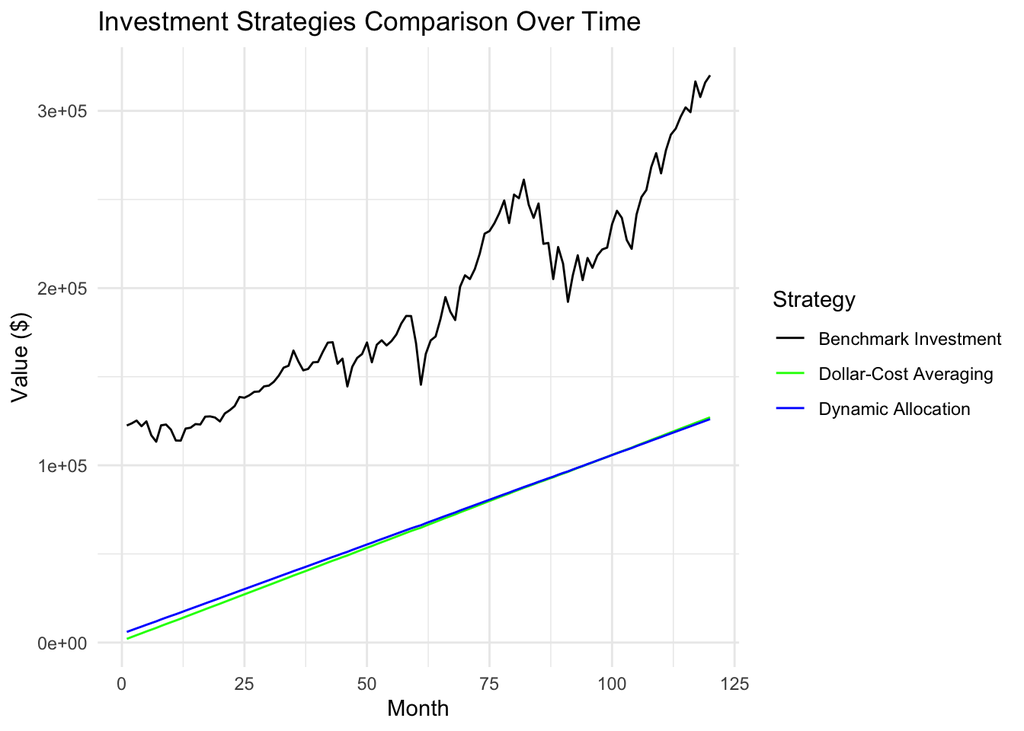

```r
ggplot(data = combined_results, aes(x = Month)) +
  geom_line(aes(y = Portfolio_Total, colour = Strategy)) +
  scale_colour_manual(values = c("Dynamic Allocation" = "blue", "Dollar-Cost Averaging" = "green", "Benchmark Investment" = "black")) +
  labs(title = "Investment Strategies Comparison Over Time", x = "Month", y = "Value ($)") +
  theme_minimal() +
  scale_linetype_manual(values = c("Savings" = "dashed")) # Differentiate savings line
```

The plot shows the cumulative value of investments over time under the three different strategies: Benchmark, Dollar-Cost Averaging, and Dynamic Allocation.

##### Comparison of Investment Strategy Returns Over Time

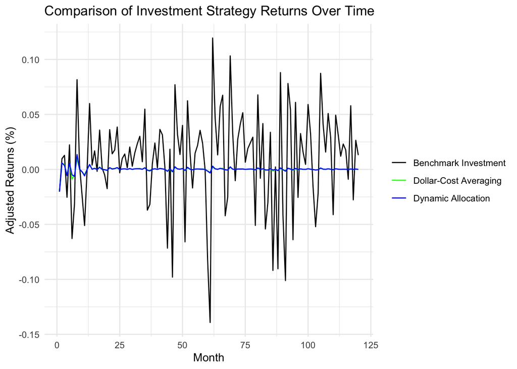

```r
ggplot(data = combined_results, aes(x = Month, y = Returns, color = Strategy)) +
  geom_line() +  # Draw lines for each strategy
  scale_color_manual(values = c("Benchmark" = "red", "Dynamic Allocation" = "blue", "Dollar-Cost Averaging" = "green", "Benchmark Investment" = "black")) +
  labs(title = "Comparison of Investment Strategy Returns Over Time",
       x = "Month", y = "Adjusted Returns (%)") +
  theme_minimal() +
  theme(legend.title = element_blank())  # Remove the legend title
```

This plot illustrates the adjusted monthly returns of each strategy.

Benchmark Investment seems to have the highest variability in returns, which may reflect the compounded effect of market movements on the lump sum investment. Dollar-Cost Averaging and Dynamic Allocation show lower volatility in returns, but the Dynamic Allocation strategy has more pronounced peaks and troughs, suggesting that it’s more responsive to market conditions than DCA.

#### Filter results by strategy

This manipulation allows us to divide our dataframes according to strategies

```r
benchmark_results <- combined_results[combined_results$Strategy == "Benchmark Investment",]
dynamic_results <- combined_results[combined_results$Strategy == "Dynamic Allocation",]
dca_results <- combined_results[combined_results$Strategy == "Dollar-Cost Averaging",]
```

## Performance Metrics

The performance metrics offers a detailed comparison of each strategy’s average return, geometric return, volatility, Sharpe Ratio, Value at Risk, and Maximum Drawdown across different ETFs. These metrics can help to evaluate the trade-offs between return and risk associated with each investment strategy.

#### Definition of functions

```r
#Max drawdown function
calculate_max_drawdown <- function(returns, months) {
  # Assuming months start from a particular point in time ; April 2014
  start_date <- as.Date("2014-04-30")  # Change this base date as needed
  dates <- seq.Date(from = start_date, by = "month", length.out = length(months))

  # Create the xts object
  returns_xts <- xts(returns, order.by = dates)

  # Calculate Maximum Drawdown
  max_dd <- maxDrawdown(returns_xts)
  return(max_dd)
}


calculate_metrics <- function(data) {
  # Ensure data is cleaned of NAs specifically in 'Returns' and 'Month'
  data <- na.omit(data[, c("Returns", "Month")])

  returns <- as.numeric(data$Returns)
  months <- data$Month  # This is assuming 'Month' is correctly ordered and represents your time series

  average_return <- mean(returns)
  geometric_return <- exp(mean(log(1 + returns))) - 1
  volatility <- sd(returns)
  sharpe_ratio <- ifelse(volatility > 0, average_return / volatility, NA)
  var <- as.numeric(quantile(returns, 0.05, na.rm = TRUE) * -1)
  max_drawdown <- as.numeric(calculate_max_drawdown(returns, months))  # Pass months instead of dates

  return(list(
    average_return = average_return,
    geometric_return = geometric_return,
    volatility = volatility,
    sharpe_ratio = sharpe_ratio,
    var = var,
    max_drawdown = max_drawdown
  ))
}
```

#### Data processing and results of the metrics

```r
benchmark_metrics <- calculate_metrics(benchmark_results)
dynamic_metrics <- calculate_metrics(dynamic_results)
dca_metrics <- calculate_metrics(dca_results)

# Convert each list of metrics to a data frame
benchmark_df <- as.data.frame(t(unlist(benchmark_metrics)))
dynamic_df <- as.data.frame(t(unlist(dynamic_metrics)))
dca_df <- as.data.frame(t(unlist(dca_metrics)))

# Add a strategy column to each dataframe
benchmark_df$Strategy <- "Benchmark"
dynamic_df$Strategy <- "Dynamic Allocation"
dca_df$Strategy <- "Dollar-Cost Averaging"

# Combine all data frames into one
combined_metrics_df <- rbind(benchmark_df, dynamic_df, dca_df)

# Optionally, set column names if they are not set
colnames(combined_metrics_df) <- c("Average.Return", "Geometric.Return", "Volatility", "Sharpe.Ratio", "Value.at.Risk", "Maximum.Drawdown", "Strategy")

# Create a better formatted table
kable(combined_metrics_df,
      format = "html",
      digits = 6,
      caption = "Performance Metrics by Strategy",
      col.names = c("Average Return", "Geometric Return", "Volatility", "Sharpe Ratio", "Value at Risk", "Maximum Drawdown", "Strategy")) %>%
  kable_styling(
    bootstrap_options = c("striped", "hover", "condensed", "responsive"),
    full_width = FALSE,
    position = "center"
  ) %>%
  column_spec(1:6, width = "100px") %>%
  row_spec(0, bold = TRUE)
```

Performance Metrics by Strategy

| Average Return | Geometric Return | Volatility | Sharpe Ratio | Value at Risk | Maximum Drawdown | Strategy |
| --- | --- | --- | --- | --- | --- | --- |
| 0.008856 | 0.007867 | 0.044428 | 0.199334 | 0.072151 | 0.263922 | Benchmark |
| 0.000090 | 0.000086 | 0.002767 | 0.032412 | 0.002124 | 0.022156 | Dynamic Allocation |
| 0.000030 | 0.000026 | 0.002642 | 0.011292 | 0.002383 | 0.024091 | Dollar-Cost Averaging |

## New version of the Value Averaging strategy,

This model allows an allocation more proportional to the last month’s performance and can be optimized by maximizing its sharpe ratio.

#### Definition of the functions

```r
calculate_investment_dynamic_updated <- function(savings, returns, value_averaging_weight) {

  # Définir le montant de base à investir
  base_investment <- 1000

  # Adjust the multiplier according to the return from the last period
  investment_multiplier <- 1 + (as.numeric(returns)*value_averaging_weight)

  # Calculate the investment amount, without exceeding what savings allow after a minimum safety reserve
  investment <- min(base_investment * investment_multiplier, savings - 400)

  # Make sure the investment is not negative
  investment <- max(investment, 0)

  return(investment)
}

# Define the new dynamic allocation function for VA strategy
dynamic_allocation_updated <- function(initial_savings, monthly_savings, data, value_averaging_weight) {
  savings <- initial_savings
  investment_portfolio <- 0
  total_invested <- 0
  total_units <- 0
  max_portfolio_value <- 0
  monthly_investment <- 0
  investment_gains <- 0
  units_to_buy <- 0
  actual_investment <- 0
  results <- data.frame(Month = integer(), Strategy = character(), Monthly_investment = numeric(), Savings = numeric(), Portfolio = numeric(), PRU = numeric(), Drawdown = numeric())

  for (month in 1:(nrow(data) - 1)) {
    returns <- data$returns[month]
    monthly_investment <- calculate_investment_dynamic_updated(savings, returns, value_averaging_weight)
    units_to_buy <- floor(monthly_investment / monthly_prices_df$prices[month])
    actual_investment <- units_to_buy * monthly_prices_df$prices[month]
    savings <- savings + monthly_savings - actual_investment
    previous_portfolio_value <- investment_portfolio
    investment_gains <- units_to_buy * monthly_prices_df$prices[month] * (1+data$returns[month+1])
    investment_portfolio <- investment_portfolio + investment_gains
    adjusted_portfolio_value <- previous_portfolio_value + actual_investment
    adjusted_return <- (investment_portfolio - adjusted_portfolio_value) / adjusted_portfolio_value
    total_invested <- total_invested + actual_investment
    total_units <- total_units + units_to_buy
    current_pru <- ifelse(total_units > 0, total_invested / total_units, 0)
    max_portfolio_value <- max(max_portfolio_value, investment_portfolio)
    current_drawdown <- (investment_portfolio - max_portfolio_value) / max_portfolio_value

    # Update portfolio and results after buying new units
    results <- rbind(
      results,
      data.frame(
        Month = month,
        Strategy = "Dynamic Allocation Updated",
        Total_units = total_units,
        Total_invested = total_invested,
        Units_to_buy = units_to_buy,
        Actual_investment = actual_investment,
        Savings = savings,
        Portfolio_assets = investment_portfolio,
        Portfolio_Total = investment_portfolio + savings,
        PRU = current_pru,
        Returns = adjusted_return
      )
    )
  }

  return(results)
}
```

#### Results of the updated strategy

```r
simulation_dynamic_updated <- dynamic_allocation_updated(5000, 1000, monthly_returns_df,10)
simulation_dynamic_updated
```

| Month | Strategy | Total_units | Total_invested | Units_to_buy | Actual_investment | Savings | Portfolio_assets | Portfolio_Total | PRU | Returns |
| --- | --- | --- | --- | --- | --- | --- | --- | --- | --- | --- |
| 1 | Dynamic Allocation Updated | 4 | 842.64 | 4 | 842.64 | 5157.36 | 825.5478 | 5982.908 | 210.6600 | -2.028414e-02 |
| 2 | Dynamic Allocation Updated | 7 | 1461.93 | 3 | 619.29 | 5538.07 | 1450.8981 | 6988.968 | 208.8471 | 4.194445e-03 |
| 3 | Dynamic Allocation Updated | 12 | 2504.23 | 5 | 1042.30 | 5495.77 | 2506.5126 | 8002.283 | 208.6858 | 5.340353e-03 |
| 4 | Dynamic Allocation Updated | 17 | 3559.93 | 5 | 1055.70 | 5440.07 | 3535.4257 | 8975.496 | 209.4076 | -7.519751e-03 |
| 5 | Dynamic Allocation Updated | 20 | 4177.48 | 3 | 617.55 | 5822.52 | 4166.7705 | 9989.290 | 208.8740 | 3.321656e-03 |
| 6 | Dynamic Allocation Updated | 25 | 5229.98 | 5 | 1052.50 | 5770.02 | 5153.0822 | 10923.102 | 209.1992 | -1.268151e-02 |
| 7 | Dynamic Allocation Updated | 26 | 5427.65 | 1 | 197.67 | 6572.35 | 5344.6180 | 11916.968 | 208.7558 | -1.146418e-03 |
| 8 | Dynamic Allocation Updated | 29 | 6002.54 | 3 | 574.89 | 6997.46 | 5966.4392 | 12963.899 | 206.9841 | 7.928217e-03 |
| 9 | Dynamic Allocation Updated | 37 | 7665.98 | 8 | 1663.44 | 6334.02 | 7635.9481 | 13969.968 | 207.1886 | 7.954246e-04 |
| 10 | Dynamic Allocation Updated | 41 | 8500.74 | 4 | 834.76 | 6499.26 | 8451.2020 | 14950.462 | 207.3351 | -2.302779e-03 |

[output cut: 110 more lines]

This shows the performance of an updated version of the Dynamic Allocation strategy across ten months. “Total_units” and “Total_invested” both steadily increase, which suggests consistent investment over time. “Units_to_buy” varies, indicating that the investment amount each month is dynamic, likely in response to changes in the market conditions as designed by the updated strategy. “Actual_investment” also fluctuates, suggesting that the investment each month changes, which aligns with the core principle of the Dynamic Allocation strategy that adapts to market conditions.

### Sharpe ratio optimization (Value-Averaging strategy)

The code tries to find the optimal weight that maximizes the Sharpe Ratio for the Value-Averaging strategy. A sequence of weights is tested, and the Sharpe Ratio is calculated for the portfolio’s returns resulting from each weight. The weight yielding the highest Sharpe Ratio is selected.

#### Definition of the sharpe ratio function

```r
calculate_sharpe_ratio <- function(returns) {
  # Clean NA values from returns first
  returns <- na.omit(returns)

  # Check if returns has enough data
  if (length(returns) < 2 || var(returns) == 0) {
    return(NA)  # Return NA if not enough data or no variation
  }

  # Compute average return and standard deviation
  average_return <- mean(returns, na.rm = TRUE)
  sd_return <- sd(returns, na.rm = TRUE)

  # Prevent division by zero
  if (sd_return == 0) {
    return(NA)
  }

  # Calculate Sharpe Ratio
  sharpe_ratio <- average_return / sd_return
  return(sharpe_ratio)
}
```

```r
test_weights <- seq(0, 500, by = 1)  # Test weights from 0 to 500 with a step of 1
sharpe_ratios <- numeric(length(test_weights))
names(sharpe_ratios) <- as.character(test_weights)

for (weight in test_weights) {
  dynamic_results <- dynamic_allocation_updated(5000, 1000, monthly_returns_df, weight)
  returns <- dynamic_results$Returns
  sharpe_ratios[as.character(weight)] <- calculate_sharpe_ratio(returns)
}

# Identification du poids qui maximise le Sharpe Ratio
best_weight <- test_weights[which.max(sharpe_ratios)]
best_sharpe_ratio <- max(sharpe_ratios)
```

## Comparison of strategies based on several etfs

Now, we would like to do the same analysis with several ETFs which are exposed to different markets (eg: world, US, emerging…) in order to see if their exposure impacts the sharpe ratio. Also, this method will allow us to have more samples to determine which strategy is better.

#### ETF selection

To perform a comparative analysis of several ETFs exposed to different markets, I chose these ETF :

- World : MSCI World Index ETF (URTH)
- US : S&P 500 ETF (SPY)
- Emerging markets : MSCI Emerging Markets ETF (EEM)
- Europe : STOXX Europe 600 ETF (FEZ)
- Asia : Asia Pacific Excluding Japan ETF (AAXJ)

```r
etfs <- c("URTH", "SPY", "EEM", "FEZ", "AAXJ")
etf_data_list <- list()
```

#### Application and storage of the different strategies on ETFs

```r
# List to store results for each ETF
etf_results <- list()
results <- list()
optimize_value_averaging_weight <- function(etf_data) {
    best_sharpe <- -Inf
    best_weight <- NULL
    test_weights <- seq(0, 100, by = 1)

    for (weight in test_weights) {
        dynamic_results <- dynamic_allocation_updated(5000, 1000, etf_data, weight)
        returns <- dynamic_results$Returns  # Ensure this column is correct and exists
        returns <- na.omit(returns)  # Clean NA values before processing
        sharpe_ratio <- calculate_sharpe_ratio(returns)

        if (!is.na(sharpe_ratio) && sharpe_ratio > best_sharpe) {
            best_sharpe <- sharpe_ratio
            best_weight <- weight
        }
    }

    return(list(best_weight = best_weight, best_sharpe = best_sharpe))
}


for (etf in etfs) {
  # Download and prepare data for this ETF
  getSymbols(etf, src = "yahoo", from = as.Date(Sys.Date()) - 365.25*10, to = Sys.Date(), auto.assign = TRUE)
  monthly_prices <- to.monthly(get(etf), indexAt = "lastof", OHLC = FALSE)
  monthly_returns <- na.omit(periodReturn(monthly_prices, period = 'monthly', type = 'log'))
  etf_data <- data.frame(date = index(monthly_returns), returns = as.numeric(coredata(monthly_returns)), prices = as.numeric(coredata(monthly_prices[,4])))

  # Find the best weight to maximize the Sharpe Ratio
  optimization_results <- optimize_value_averaging_weight(etf_data)
  best_weight <- optimization_results$best_weight
  best_sharpe <- optimization_results$best_sharpe

  # Apply investment strategies
  benchmark_results <- benchmark_investment_strategy(125000, etf_data)
  dca_results <- dollar_cost_averaging(1041.67, 1041.67, etf_data)
  dynamic_results <- dynamic_allocation_updated(5000, 1000, etf_data, best_weight)

   # Calculation of metrics for each strategy
  benchmark_metrics <- calculate_metrics(benchmark_results)
  dca_metrics <- calculate_metrics(dca_results)
  dynamic_metrics <- calculate_metrics(dynamic_results)


# Store results in list
  results[[etf]] <- list(
    Benchmark = benchmark_results,
    DCA = dca_results,
    Dynamic = dynamic_results,
    BestWeight = best_weight,
    BestSharpe = best_sharpe
  )
# Store metrics results
  etf_results[[etf]] <- list(
    Benchmark = benchmark_metrics,
    DCA = dca_metrics,
    Dynamic = dynamic_metrics
  )
}
```

#### Combining results in one dataframe

```r
# Create metrics dataframe
all_metrics_df <- data.frame(
  ETF = character(),
  Strategy = character(),
  Average.Return = numeric(),
  Geometric.Return = numeric(),
  Volatility = numeric(),
  Sharpe.Ratio = numeric(),
  Value.at.Risk = numeric(),
  Maximum.Drawdown = numeric(),
  stringsAsFactors = FALSE
)

# Add data for each ETF and strategy
for (etf in etfs) {
  # Calculate metrics for benchmark strategy
  benchmark_metrics <- calculate_metrics(benchmark_results)
  all_metrics_df <- rbind(all_metrics_df,
                         data.frame(ETF = etf,
                                  Strategy = "Benchmark",
                                  Average.Return = benchmark_metrics$average_return,
                                  Geometric.Return = benchmark_metrics$geometric_return,
                                  Volatility = benchmark_metrics$volatility,
                                  Sharpe.Ratio = benchmark_metrics$sharpe_ratio,
                                  Value.at.Risk = benchmark_metrics$var,
                                  Maximum.Drawdown = benchmark_metrics$max_drawdown))

  # Calculate metrics for DCA strategy
  dca_metrics <- calculate_metrics(dca_results)
  all_metrics_df <- rbind(all_metrics_df,
                         data.frame(ETF = etf,
                                  Strategy = "DCA",
                                  Average.Return = dca_metrics$average_return,
                                  Geometric.Return = dca_metrics$geometric_return,
                                  Volatility = dca_metrics$volatility,
                                  Sharpe.Ratio = dca_metrics$sharpe_ratio,
                                  Value.at.Risk = dca_metrics$var,
                                  Maximum.Drawdown = dca_metrics$max_drawdown))

  # Calculate metrics for dynamic strategy
  dynamic_metrics <- calculate_metrics(dynamic_results)
  all_metrics_df <- rbind(all_metrics_df,
                         data.frame(ETF = etf,
                                  Strategy = "Dynamic",
                                  Average.Return = dynamic_metrics$average_return,
                                  Geometric.Return = dynamic_metrics$geometric_return,
                                  Volatility = dynamic_metrics$volatility,
                                  Sharpe.Ratio = dynamic_metrics$sharpe_ratio,
                                  Value.at.Risk = dynamic_metrics$var,
                                  Maximum.Drawdown = dynamic_metrics$max_drawdown))
}

# Calculate metric averages for all ETFs
average_metrics_df <- all_metrics_df %>%
  group_by(Strategy) %>%
  summarise(
    Average.Return = mean(Average.Return, na.rm = TRUE),
    Geometric.Return = mean(Geometric.Return, na.rm = TRUE),
    Volatility = mean(Volatility, na.rm = TRUE),
    Sharpe.Ratio = mean(Sharpe.Ratio, na.rm = TRUE),
    Value.at.Risk = mean(Value.at.Risk, na.rm = TRUE),
    Maximum.Drawdown = mean(Maximum.Drawdown, na.rm = TRUE)
  )

# Format numbers to be more readable
average_metrics_df_formatted <- average_metrics_df %>%
  mutate(across(where(is.numeric), ~round(., 6)))

# Find best and worst performing strategies
max_sharpe_avg <- which.max(average_metrics_df$Sharpe.Ratio)
min_sharpe_avg <- which.min(average_metrics_df$Sharpe.Ratio)

# Create and display the table
kable(average_metrics_df_formatted,
      format = "html",
      caption = "Average Performance Metrics Across All Strategies",
      digits = 6) %>%
  kable_styling(bootstrap_options = c("striped", "hover", "condensed"),
                full_width = FALSE,
                position = "center") %>%
  row_spec(max_sharpe_avg, background = "#90EE90") %>%  # Light green
  row_spec(min_sharpe_avg, background = "#FFB6C1") %>%  # Light red
  column_spec(1:7, width = "100px")
```

Average Performance Metrics Across All Strategies

| Strategy | Average.Return | Geometric.Return | Volatility | Sharpe.Ratio | Value.at.Risk | Maximum.Drawdown |
| --- | --- | --- | --- | --- | --- | --- |
| Benchmark | 0.001377 | 0.000126 | 0.050167 | 0.027451 | 0.073845 | 0.425711 |
| DCA | 0.000030 | 0.000020 | 0.004398 | 0.006751 | 0.002940 | 0.055092 |
| Dynamic | 0.000314 | 0.000307 | 0.003899 | 0.080632 | 0.002145 | 0.018398 |

## Conclusion

We saw that investment strategies can vary widely in effectiveness depending on the market conditions represented by different ETFs.

The benchmark strategy, which represents a lump-sum investment, can sometimes lead to higher average returns but also comes with higher volatility and drawdowns, highlighting the trade-off between risk and return.

In terms of investment, while the Dynamic Allocation strategy seems to provide a good balance between risk and return, individual investors must consider their risk tolerance, investment horizon, and the specific market conditions of the ETFs they are interested in before choosing a strategy.

The dynamic allocation strategy is particularly suitable for someone with a steady income who can save monthly, rather than investing a large sum all at once. It’s more attuned to the typical financial situation of a salaried employee, allowing for regular investments that align with monthly cash flow, mitigating risk, and potentially maximizing returns through strategic adjustments based on market conditions. This approach can offer a practical and less daunting path to investment compared to a one-time, upfront benchmark investment strategy.

## Annexes

Then I would like to perform the analysis based on different time horizons and see if some strategies are better than others based on that.

Unfortunately I did not have time to finish this part of the code but it seemed interesting to me to share with you the various future improvements for this project.

```r
etfs <- c("URTH", "SPY", "EEM", "FEZ", "AAXJ")
time_horizons <- c("1 year" = 365.25, "2 years" = 2 * 365.25, "5 years" = 5 * 365.25, "10 years" = 10 * 365.25, "20 years" = 20 * 365.25)

standard_columns <- c("Average Return", "Geometric Return", "Volatility", "Sharpe Ratio", "Value at Risk", "Maximum Drawdown", "ETF", "Strategy")

calculate_etf_metrics <- function(etf, years) {
  start_date <- as.Date(Sys.Date()) - years
  getSymbols(etf, src = "yahoo", from = start_date, to = Sys.Date(), auto.assign = TRUE)
  monthly_prices <- to.monthly(get(etf), indexAt = "lastof", OHLC = FALSE)
  monthly_returns <- na.omit(periodReturn(monthly_prices, period = 'monthly', type = 'log'))
  etf_data <- data.frame(date = index(monthly_returns), returns = as.numeric(coredata(monthly_returns)), prices = as.numeric(coredata(monthly_prices[,4])))

  if (nrow(etf_data) > 0) {
    optimization_results <- optimize_value_averaging_weight(etf_data)
    best_weight <- optimization_results$best_weight

    benchmark_results <- benchmark_investment_strategy(125000, etf_data)
    dca_results <- dollar_cost_averaging(1041.67, 1041.67, etf_data)
    dynamic_results <- dynamic_allocation_updated(5000, 1000, etf_data, best_weight)

    return(list(
      Benchmark = calculate_metrics(benchmark_results),
      DCA = calculate_metrics(dca_results),
      Dynamic = calculate_metrics(dynamic_results),
      BestWeight = best_weight,
      BestSharpe = optimization_results$best_sharpe
    ))
  } else {
    return(list())
  }
}

results_by_time_horizon <- lapply(time_horizons, function(years) {
  sapply(etfs, function(etf) calculate_etf_metrics(etf, years), simplify = FALSE)
})

# Create a dataframe to store all results
all_results_df <- data.frame()
```

### Performance Metrics for 1 year across ETFs

Performance Metrics for 1 year across ETFs

| Average Return | Geometric Return | Volatility | Sharpe Ratio | Value at Risk | Maximum Drawdown | ETF | Strategy | Period |
| --- | --- | --- | --- | --- | --- | --- | --- | --- |
| 0.012795 | 0.012393 | 0.029577 | 0.432600 | 0.037783 | 0.040417 | URTH | Benchmark | 1 |
| 0.003436 | 0.003360 | 0.012851 | 0.267338 | 0.012649 | 0.023741 | URTH | DCA | 1 |
| 0.003759 | 0.003693 | 0.012103 | 0.310628 | 0.010727 | 0.019681 | URTH | Dynamic | 1 |
| 0.015194 | 0.014810 | 0.029015 | 0.523669 | 0.033763 | 0.041155 | SPY | Benchmark | 1 |
| 0.003602 | 0.003532 | 0.012357 | 0.291502 | 0.012418 | 0.024207 | SPY | DCA | 1 |
| 0.004011 | 0.003950 | 0.011561 | 0.346902 | 0.010484 | 0.020074 | SPY | Dynamic | 1 |
| 0.008736 | 0.008378 | 0.028032 | 0.311655 | 0.032410 | 0.089424 | EEM | Benchmark | 1 |
| 0.003656 | 0.003625 | 0.008310 | 0.440006 | 0.003493 | 0.009990 | EEM | DCA | 1 |
| 0.004131 | 0.004103 | 0.007848 | 0.526346 | 0.002109 | 0.002562 | EEM | Dynamic | 1 |
| 0.006813 | 0.005835 | 0.046278 | 0.147219 | 0.057001 | 0.097743 | FEZ | Benchmark | 1 |
| 0.002210 | 0.002114 | 0.014549 | 0.151916 | 0.017052 | 0.023344 | FEZ | DCA | 1 |
| 0.002334 | 0.002242 | 0.014242 | 0.163918 | 0.016442 | 0.019834 | FEZ | Dynamic | 1 |
| 0.011162 | 0.010760 | 0.029856 | 0.373873 | 0.029814 | 0.081028 | AAXJ | Benchmark | 1 |
| 0.004623 | 0.004588 | 0.008813 | 0.524602 | 0.003198 | 0.009034 | AAXJ | DCA | 1 |
| 0.005226 | 0.005194 | 0.008315 | 0.628448 | 0.001193 | 0.002652 | AAXJ | Dynamic | 1 |

### Performance Metrics for 2 years across ETFs

Performance Metrics for 2 years across ETFs

| Average Return | Geometric Return | Volatility | Sharpe Ratio | Value at Risk | Maximum Drawdown | ETF | Strategy | Period |
| --- | --- | --- | --- | --- | --- | --- | --- | --- |
| 0.015048 | 0.014524 | 0.033243 | 0.452678 | 0.039698 | 0.090410 | URTH | Benchmark | 2 |
| 0.002923 | 0.002895 | 0.007604 | 0.384391 | 0.003246 | 0.013278 | URTH | DCA | 2 |
| 0.003086 | 0.003059 | 0.007443 | 0.414565 | 0.003549 | 0.007939 | URTH | Dynamic | 2 |
| 0.017954 | 0.017424 | 0.033460 | 0.536588 | 0.039139 | 0.088112 | SPY | Benchmark | 2 |
| 0.003317 | 0.003290 | 0.007675 | 0.432262 | 0.002822 | 0.013131 | SPY | DCA | 2 |
| 0.003659 | 0.003633 | 0.007530 | 0.485946 | 0.003039 | 0.007188 | SPY | Dynamic | 2 |
| 0.006244 | 0.005589 | 0.037011 | 0.168693 | 0.044449 | 0.128248 | EEM | Benchmark | 2 |
| 0.001576 | 0.001544 | 0.008195 | 0.192298 | 0.007636 | 0.018384 | EEM | DCA | 2 |
| 0.002394 | 0.002357 | 0.008800 | 0.272001 | 0.006602 | 0.007414 | EEM | Dynamic | 2 |
| 0.010424 | 0.009331 | 0.047948 | 0.217398 | 0.057582 | 0.128116 | FEZ | Benchmark | 2 |
| 0.002881 | 0.002818 | 0.011634 | 0.247645 | 0.009329 | 0.021504 | FEZ | DCA | 2 |
| 0.003728 | 0.003664 | 0.011711 | 0.318335 | 0.005915 | 0.008211 | FEZ | Dynamic | 2 |
| 0.005829 | 0.005127 | 0.038276 | 0.152279 | 0.051197 | 0.132685 | AAXJ | Benchmark | 2 |
| 0.001381 | 0.001341 | 0.009200 | 0.150117 | 0.009954 | 0.019629 | AAXJ | DCA | 2 |
| 0.002062 | 0.002019 | 0.009569 | 0.215525 | 0.007306 | 0.015067 | AAXJ | Dynamic | 2 |

### Performance Metrics for 5 years across ETFs

Performance Metrics for 5 years across ETFs

| Average Return | Geometric Return | Volatility | Sharpe Ratio | Value at Risk | Maximum Drawdown | ETF | Strategy | Period |
| --- | --- | --- | --- | --- | --- | --- | --- | --- |
| 0.010017 | 0.008737 | 0.050736 | 0.197441 | 0.088064 | 0.276579 | URTH | Benchmark | 5 |
| -0.000283 | -0.000505 | 0.020470 | -0.013845 | 0.003755 | 0.140325 | URTH | DCA | 5 |
| -0.000430 | -0.000643 | 0.019985 | -0.021521 | 0.003719 | 0.140325 | URTH | Dynamic | 5 |
| 0.012029 | 0.010700 | 0.051683 | 0.232741 | 0.090445 | 0.263922 | SPY | Benchmark | 5 |
| -0.000042 | -0.000272 | 0.020960 | -0.002001 | 0.003704 | 0.139247 | SPY | DCA | 5 |
| -0.000165 | -0.000383 | 0.020318 | -0.008099 | 0.003369 | 0.139247 | SPY | Dynamic | 5 |
| 0.001528 | 0.000155 | 0.052404 | 0.029155 | 0.069074 | 0.391340 | EEM | Benchmark | 5 |
| -0.001223 | -0.001524 | 0.023395 | -0.052282 | 0.002606 | 0.171619 | EEM | DCA | 5 |
| -0.001291 | -0.001586 | 0.023189 | -0.055654 | 0.002537 | 0.171619 | EEM | Dynamic | 5 |
| 0.007087 | 0.004779 | 0.068204 | 0.103902 | 0.083155 | 0.388831 | FEZ | Benchmark | 5 |
| -0.001652 | -0.002050 | 0.026618 | -0.062046 | 0.005702 | 0.197956 | FEZ | DCA | 5 |
| -0.001577 | -0.001975 | 0.026634 | -0.059209 | 0.005238 | 0.197956 | FEZ | Dynamic | 5 |
| 0.001616 | 0.000210 | 0.053576 | 0.030170 | 0.073845 | 0.425711 | AAXJ | Benchmark | 5 |
| -0.000728 | -0.000916 | 0.018813 | -0.038680 | 0.002485 | 0.134828 | AAXJ | DCA | 5 |
| -0.000791 | -0.000975 | 0.018570 | -0.042575 | 0.002294 | 0.134828 | AAXJ | Dynamic | 5 |

### Performance Metrics for 10 years across ETFs

Performance Metrics for 10 years across ETFs

| Average Return | Geometric Return | Volatility | Sharpe Ratio | Value at Risk | Maximum Drawdown | ETF | Strategy | Period |
| --- | --- | --- | --- | --- | --- | --- | --- | --- |
| 0.006549 | 0.005595 | 0.043591 | 0.150231 | 0.074627 | 0.276579 | URTH | Benchmark | 10 |
| 0.000003 | 0.000000 | 0.002509 | 0.001072 | 0.002627 | 0.021044 | URTH | DCA | 10 |
| -0.000019 | -0.000022 | 0.002579 | -0.007263 | 0.002357 | 0.025360 | URTH | Dynamic | 10 |
| 0.008856 | 0.007867 | 0.044428 | 0.199334 | 0.072151 | 0.263922 | SPY | Benchmark | 10 |
| 0.000030 | 0.000026 | 0.002642 | 0.011292 | 0.002383 | 0.024091 | SPY | DCA | 10 |
| 0.000023 | 0.000019 | 0.002742 | 0.008479 | 0.002261 | 0.027853 | SPY | Dynamic | 10 |
| 0.000719 | -0.000505 | 0.049486 | 0.014525 | 0.068945 | 0.391340 | EEM | Benchmark | 10 |
| -0.000144 | -0.000155 | 0.004846 | -0.029671 | 0.005355 | 0.060604 | EEM | DCA | 10 |
| 0.000037 | 0.000028 | 0.004186 | 0.008833 | 0.003323 | 0.034114 | EEM | Dynamic | 10 |
| 0.002814 | 0.001180 | 0.057211 | 0.049185 | 0.082556 | 0.388831 | FEZ | Benchmark | 10 |
| -0.000139 | -0.000143 | 0.002847 | -0.048737 | 0.005000 | 0.033025 | FEZ | DCA | 10 |
| -0.000178 | -0.000182 | 0.002920 | -0.060977 | 0.004991 | 0.037084 | FEZ | Dynamic | 10 |
| 0.001377 | 0.000126 | 0.050167 | 0.027451 | 0.073845 | 0.425711 | AAXJ | Benchmark | 10 |
| 0.000030 | 0.000020 | 0.004398 | 0.006751 | 0.002940 | 0.055092 | AAXJ | DCA | 10 |
| 0.000314 | 0.000307 | 0.003899 | 0.080632 | 0.002145 | 0.018398 | AAXJ | Dynamic | 10 |

### Performance Metrics for 20 years across ETFs

Performance Metrics for 20 years across ETFs

| Average Return | Geometric Return | Volatility | Sharpe Ratio | Value at Risk | Maximum Drawdown | ETF | Strategy | Period |
| --- | --- | --- | --- | --- | --- | --- | --- | --- |
| 0.007342 | 0.006484 | 0.041321 | 0.177680 | 0.069190 | 0.276579 | URTH | Benchmark | 20 |
| 0.000673 | 0.000656 | 0.006067 | 0.111012 | 0.001357 | 0.018715 | URTH | DCA | 20 |
| 0.000653 | 0.000635 | 0.006172 | 0.105815 | 0.001218 | 0.022136 | URTH | Dynamic | 20 |
| 0.006751 | 0.005778 | 0.043777 | 0.154214 | 0.077377 | 0.544069 | SPY | Benchmark | 20 |
| -0.000046 | -0.000050 | 0.002832 | -0.016395 | 0.002395 | 0.033487 | SPY | DCA | 20 |
| 0.000074 | 0.000070 | 0.002613 | 0.028192 | 0.001944 | 0.022382 | SPY | Dynamic | 20 |
| 0.002484 | 0.000557 | 0.061320 | 0.040502 | 0.093639 | 0.658337 | EEM | Benchmark | 20 |
| -0.000119 | -0.000154 | 0.008231 | -0.014421 | 0.003560 | 0.089499 | EEM | DCA | 20 |
| 0.000939 | 0.000924 | 0.005558 | 0.169028 | 0.002012 | 0.017067 | EEM | Dynamic | 20 |
| 0.001272 | -0.000849 | 0.064341 | 0.019774 | 0.115246 | 0.695945 | FEZ | Benchmark | 20 |
| -0.000148 | -0.000155 | 0.003585 | -0.041384 | 0.003368 | 0.046096 | FEZ | DCA | 20 |
| 0.000239 | 0.000234 | 0.003153 | 0.075858 | 0.001990 | 0.027969 | FEZ | Dynamic | 20 |
| 0.002136 | 0.000364 | 0.059204 | 0.036080 | 0.086868 | 0.457263 | AAXJ | Benchmark | 20 |
| -0.002285 | -0.002541 | 0.021529 | -0.106136 | 0.004006 | 0.324915 | AAXJ | DCA | 20 |
| -0.000608 | -0.000791 | 0.018293 | -0.033256 | 0.003993 | 0.193367 | AAXJ | Dynamic | 20 |

# Create visualizations

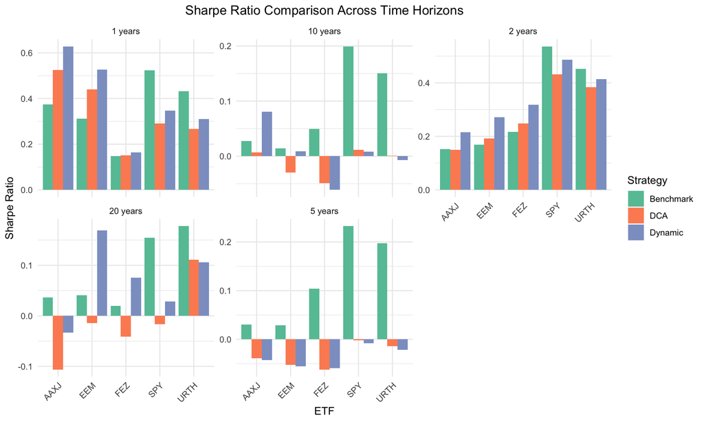

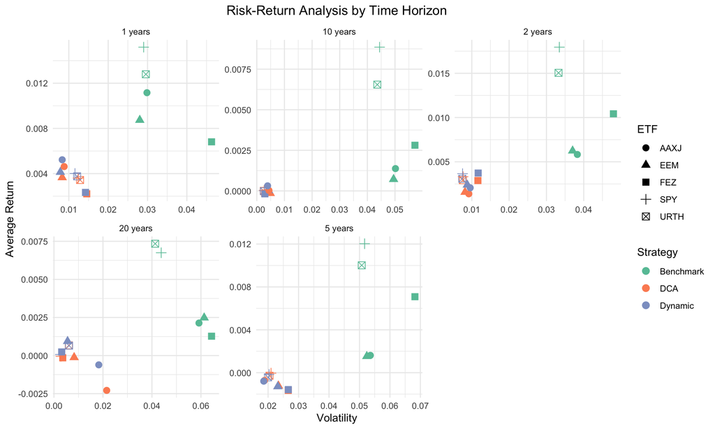

We could then have determined the best strategy in two different ways, and then taken an average.

It would be interesting to carry out the same analysis with more assets in order to have more concrete and representative results. It would also be interesting to do it with other types of assets, this is one of the strengths of these strategies, they are applicable for the majority of assets.

```r
# Creation of a dataframe to compare performance by ETF
performance_comparison <- data.frame(
  ETF = character(),
  Strategy = character(),
  Sharpe = numeric(),
  Return = numeric(),
  Risk = numeric()
)

for (etf in etfs) {
  if (!is.null(results[[etf]])) {
    for (strategy in c("Benchmark", "DCA", "Dynamic")) {
      if (!is.null(results[[etf]][[strategy]])) {
        performance_comparison <- rbind(performance_comparison, data.frame(
          ETF = etf,
          Strategy = strategy,
          Sharpe = results[[etf]][[strategy]]$sharpe_ratio,
          Return = results[[etf]][[strategy]]$average_return,
          Risk = results[[etf]][[strategy]]$volatility
        ))
      }
    }
  }
}
```

# Performance visualization

## Sharpe Ratios comparison

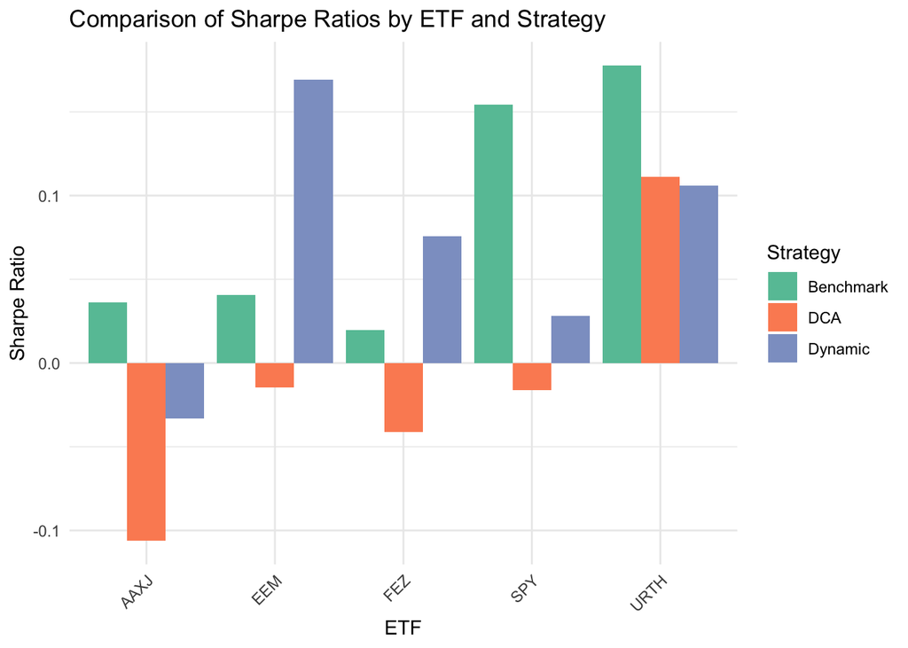

```r
# 1 Sharpe Ratio chart by ETF and Strategy
ggplot(performance_comparison, aes(x = ETF, y = Sharpe, fill = Strategy)) +
  geom_bar(stat = "identity", position = "dodge") +
  theme_minimal() +
  labs(title = "Comparison of Sharpe Ratios by ETF and Strategy",
       x = "ETF",
       y = "Sharpe Ratio") +
  theme(axis.text.x = element_text(angle = 45, hjust = 1)) +
  scale_fill_brewer(palette = "Set2")
```

Analysis of Sharpe ratios by ETF and strategy reveals several important points: - The URTH ETF (MSCI World) shows the best Sharpe ratios, particularly with the Benchmark strategy, suggesting greater efficiency for investments in global developed markets - The Benchmark strategy generally outperforms other strategies for developed market ETFs (URTH and SPY) - The Dynamic strategy shows particular efficiency for the EEM ETF (emerging markets), indicating that more volatile markets can benefit from a more adaptive approach- The DCA shows lower, even negative, Sharpe ratios, suggesting a lower efficiency of this strategy over the period studied

## Risk-return analysis

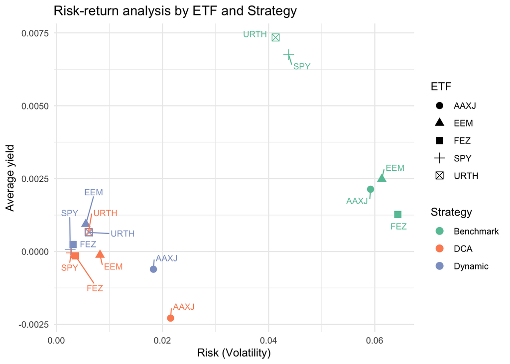

```r
# 2. Risk-return chart by ETF
ggplot(performance_comparison, aes(x = Risk, y = Return, color = Strategy, shape = ETF)) +
  geom_point(size = 3) +
  theme_minimal() +
  labs(title = "Risk-return analysis by ETF and Strategy",
       x = "Risk (Volatility)",
       y = "Average yield") +
  geom_text_repel(aes(label = ETF), size = 3, box.padding = 0.5) +
  scale_color_brewer(palette = "Set2")
```

The risk-return chart highlights several key aspects: - A clear distinction between developed (URTH, SPY) and emerging/regional market ETFs (EEM, FEZ, AAXJ) - The URTH and SPY ETFs offer the best risk-return trade-off with the Benchmark strategy, with higher returns for a moderate level of risk - The DCA and Dynamic strategies tend to reduce both risk and return, acting as more conservative strategies- The AAXJ ETF (Asia-Pacific) shows the greatest dispersion between strategies, suggesting that strategy choice has a greater impact on Asian markets

## Heatmap of Sharpe Ratios

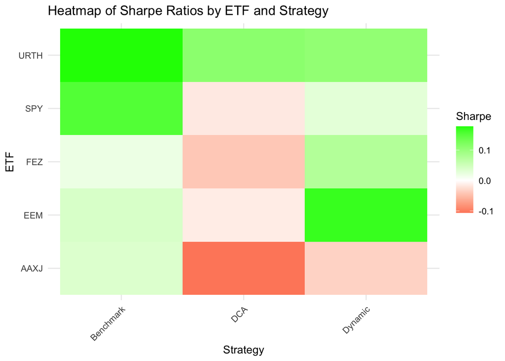

```r
# 3. Performance heatmap
performance_wide <- performance_comparison %>%
  select(ETF, Strategy, Sharpe) %>%
  spread(Strategy, Sharpe)

ggplot(performance_comparison, aes(x = Strategy, y = ETF, fill = Sharpe)) +
  geom_tile() +
  scale_fill_gradient2(low = "red", mid = "white", high = "green", midpoint = 0) +
  theme_minimal() +
  labs(title = "Heatmap of Sharpe Ratios by ETF and Strategy",
       x = "Strategy",
       y = "ETF") +
  theme(axis.text.x = element_text(angle = 45, hjust = 1))
```

The Sharpe ratio heatmap offers a clear visualization of relative performance: - The intense green areas for URTH and SPY with the Benchmark strategy confirm the superiority of this approach for developed markets - The red areas for DCA, particularly for AAXJ, indicate a significant underperformance of this strategy - The Dynamic strategy shows a more balanced performance across the different ETFs, suggesting a better adaptability to different market conditions

## Implications for the Investment Strategy

These graphical analyses allow us to draw several important conclusions for the investment strategy:

1. **Market strategy selection:**
- For developed markets (URTH, SPY): prefer the Benchmark strategy
- For emerging markets (EEM): consider the Dynamic strategy
- Avoid the DCA for long-term investments in these markets2.

**Risk considerations:** - Dynamic and DCA strategies can be used to reduce risk, but at the cost of potentially lower returns - Benchmark strategy, although riskier, offers the best risk-adjusted performance on developed markets3.

**Diversification:** - Performance differences between ETFs and strategies underline the importance of geographic diversification - Combining different strategies across markets could optimize the portfolio’s overall risk-return profile

These results suggest that a hybrid approach, adapting the strategy to the target market, could be more effective than a uniform application of a single investment strategy.